# Project 2 Code

Nidhi, Amanda, Adam

10/28/2022

## Problem Description

After Steve Rogers replaced the Infinity Stones, Stark Enterprises has branched into the financial industry. Perhaps Steve Rogers changed something when he traveled back in time. Since Mr. Stark is on a different timeline, they are short of analytical power. They would like to build a model and predict which customers are likely to have high-risk.

## Objective

In this case, we will need to select the appropriate variables to train at least 2 different models to predict the target variable. With the best model, we will predict the risk level of the new customers given.

## Describing the Data

In each of our models, we used a different set of what we believed were key variables. These variables described the customers’ wealth, background, and application.

## Model 1: Load Data

```r
Ndf <- read.csv("credit_fa2022_5.csv")
Ndf <- Ndf [ , -c(1)]
Ndf1 <- Ndf[ , c(2:11, 14:16, 42:61)]
Ndf1_clean <- drop_na(Ndf1)

head(Ndf1_clean)
```

```
##   TARGET NAME_CONTRACT_TYPE CODE_GENDER FLAG_OWN_CAR FLAG_OWN_REALTY
## 1      0         Cash loans           M            N               N
## 2      0    Revolving loans           F            N               Y
## 3      0         Cash loans           M            Y               Y
## 4      0         Cash loans           F            N               Y
## 5      0         Cash loans           M            Y               Y
## 6      0         Cash loans           F            N               Y
##   CNT_CHILDREN AMT_INCOME_TOTAL AMT_CREDIT AMT_ANNUITY AMT_GOODS_PRICE
## 1            0           112500   284400.0     16456.5          225000
## 2            1            85500   180000.0      9000.0          180000
## 3            1           157500   761872.5     59089.5          675000
## 4            0           202500   123637.5      8793.0          112500
## 5            0           144000   553806.0     26770.5          495000
## 6            0           360000  1125000.0     33025.5         1125000
##             NAME_EDUCATION_TYPE NAME_FAMILY_STATUS   NAME_HOUSING_TYPE
```

[output cut: 41 more lines]

```r
str(Ndf1_clean)
```

```
## 'data.frame':    29970 obs. of  33 variables:
##  $ TARGET             : int  0 0 0 0 0 0 0 0 0 0 ...
##  $ NAME_CONTRACT_TYPE : chr  "Cash loans" "Revolving loans" "Cash loans" "Cash loans" ...
##  $ CODE_GENDER        : chr  "M" "F" "M" "F" ...
##  $ FLAG_OWN_CAR       : chr  "N" "N" "Y" "N" ...
##  $ FLAG_OWN_REALTY    : chr  "N" "Y" "Y" "Y" ...
##  $ CNT_CHILDREN       : int  0 1 1 0 0 0 3 0 0 0 ...
##  $ AMT_INCOME_TOTAL   : num  112500 85500 157500 202500 144000 ...
##  $ AMT_CREDIT         : num  284400 180000 761873 123638 553806 ...
##  $ AMT_ANNUITY        : num  16457 9000 59090 8793 26771 ...
##  $ AMT_GOODS_PRICE    : num  225000 180000 675000 112500 495000 ...
##  $ NAME_EDUCATION_TYPE: chr  "Secondary / secondary special" "Secondary / secondary special" "Secondary / secondary special" "Secondary / secondary special" ...
##  $ NAME_FAMILY_STATUS : chr  "Civil marriage" "Married" "Married" "Married" ...
##  $ NAME_HOUSING_TYPE  : chr  "Rented apartment" "Municipal apartment" "House / apartment" "House / apartment" ...
##  $ FLAG_DOCUMENT_2    : int  0 0 0 0 0 0 0 0 0 0 ...
```

[output cut: 19 more lines]

After reading in the data, I deleted the first column, X, which simply noted which record of the entire data set this sample record was picked from. For our first model, I decided to look at the following independent variables to predict the outcome of “Target”: Whether the individual had payment difficulties and is at high risk.

Independent Variables: Contract Type, Gender, Owns Car, Owns Realty, Number of Children, Income, Credit Amount of Loan, Loan Annuity, Education, Family Status, Housing Situation, and whether they provided all their documents. I chose these variables since they seemed to represent the client’s wealth and whether or not they provided all of their documentation, which seems like strong predictors of whether they are high risk or not.

Since this is a kNN model which can not handle missing data, I dropped all records with N/A values from the data set.

## Model 1: Factorizing Data

```r
Ndf1_clean$TARGET <- factor(Ndf1_clean$TARGET,
                              levels = c("0", "1"),
                              labels = c("No", "Yes"))
Ndf1_clean[, c(2:5, 11:33)] <- lapply(Ndf1_clean[, c(2:5, 11:33)], as.factor)
str(Ndf1_clean)
```

```
## 'data.frame':    29970 obs. of  33 variables:
##  $ TARGET             : Factor w/ 2 levels "No","Yes": 1 1 1 1 1 1 1 1 1 1 ...
##  $ NAME_CONTRACT_TYPE : Factor w/ 2 levels "Cash loans","Revolving loans": 1 2 1 1 1 1 1 1 1 1 ...
##  $ CODE_GENDER        : Factor w/ 2 levels "F","M": 2 1 2 1 2 1 1 1 1 2 ...
##  $ FLAG_OWN_CAR       : Factor w/ 2 levels "N","Y": 1 1 2 1 2 1 2 1 1 1 ...
##  $ FLAG_OWN_REALTY    : Factor w/ 2 levels "N","Y": 1 2 2 2 2 2 2 2 2 2 ...
##  $ CNT_CHILDREN       : int  0 1 1 0 0 0 3 0 0 0 ...
##  $ AMT_INCOME_TOTAL   : num  112500 85500 157500 202500 144000 ...
##  $ AMT_CREDIT         : num  284400 180000 761873 123638 553806 ...
##  $ AMT_ANNUITY        : num  16457 9000 59090 8793 26771 ...
##  $ AMT_GOODS_PRICE    : num  225000 180000 675000 112500 495000 ...
##  $ NAME_EDUCATION_TYPE: Factor w/ 5 levels "Academic degree",..: 5 5 5 5 5 2 5 5 5 5 ...
##  $ NAME_FAMILY_STATUS : Factor w/ 5 levels "Civil marriage",..: 1 2 2 2 2 1 1 5 2 1 ...
##  $ NAME_HOUSING_TYPE  : Factor w/ 6 levels "Co-op apartment",..: 5 3 2 2 2 2 2 2 2 2 ...
##  $ FLAG_DOCUMENT_2    : Factor w/ 2 levels "0","1": 1 1 1 1 1 1 1 1 1 1 ...
```

[output cut: 19 more lines]

I factorized the outcome variable and all the categorical variables in the data set so the kNN runs smoothly.

## Model 1: Training-Validation Set

```r
set.seed(666)

Ntrain_index <- sample(1:nrow(Ndf1_clean), 0.7 * nrow(Ndf1_clean))
Nvalid_index <- setdiff(1:nrow(Ndf1_clean), Ntrain_index)

Ntrain <- Ndf1_clean[Ntrain_index, ]
Nvalid <- Ndf1_clean[Nvalid_index, ]

nrow(Ntrain)
```

```
## [1] 20979
```

```r
nrow(Nvalid)
```

```
## [1] 8991
```

## Model 1: Normalize Training and Validation Set

```r
Ntrain_norm <- Ntrain
Nvalid_norm <- Nvalid

Nnorm_values <- preProcess(Ntrain[, -c(1:5, 11:33)],
                          method = c("center",
                                     "scale"))
Ntrain_norm[, -c(1:5, 11:33)] <- predict(Nnorm_values,
                               Ntrain[, -c(1:5, 11:33)])

Nvalid_norm[, -c(1:5, 11:33)] <- predict(Nnorm_values,
                                Nvalid[, -c(1:5, 11:33)])
head(Nvalid_norm)
```

```
##    TARGET NAME_CONTRACT_TYPE CODE_GENDER FLAG_OWN_CAR FLAG_OWN_REALTY
## 2      No    Revolving loans           F            N               Y
## 3      No         Cash loans           M            Y               Y
## 6      No         Cash loans           F            N               Y
## 9      No         Cash loans           F            N               Y
## 10     No         Cash loans           M            N               Y
## 12    Yes         Cash loans           F            Y               N
##    CNT_CHILDREN AMT_INCOME_TOTAL AMT_CREDIT AMT_ANNUITY AMT_GOODS_PRICE
## 2     0.7918812      -0.80077763 -1.0488346  -1.2644130      -0.9703849
## 3     0.7918812      -0.09857984  0.4437556   2.2762321       0.4151791
## 6    -0.5850666       1.87635143  1.3752321   0.4338625       1.6747827
## 9    -0.5850666       1.43747781  3.5777506   1.9645052       3.4886119
## 10   -0.5850666       0.55973058 -0.2025352   1.8019619      -0.1516425
## 12   -0.5850666       0.55973058 -0.3612307  -0.4151162      -0.5925038
##              NAME_EDUCATION_TYPE NAME_FAMILY_STATUS   NAME_HOUSING_TYPE
```

[output cut: 41 more lines]

I normalized the training and validation set separately since the model only is built off of the training set. In our scenario, the validation set is almost treated like “new data” so it shouldn’t be normalized with the training set.

## Model 1: Load in New Customers and Normalize

```r
Nnew_cust <- read.csv("credit_test_fa2022_5.csv")
Nnew_cust<- Nnew_cust [ , -c(1)]
Nnew_cust1 <- Nnew_cust[ , c(2:10, 13:15, 41:60)]
Nnew_cust1 <- drop_na(Nnew_cust1)

Nnew_cust1[, c(1:4, 10:32)] <- lapply(Nnew_cust1[, c(1:4, 10:32)], as.factor)

str(Nnew_cust1)
```

```
## 'data.frame':    5 obs. of  32 variables:
##  $ NAME_CONTRACT_TYPE : Factor w/ 1 level "Cash loans": 1 1 1 1 1
##  $ CODE_GENDER        : Factor w/ 1 level "FALSE": 1 1 1 1 1
##  $ FLAG_OWN_CAR       : Factor w/ 1 level "N": 1 1 1 1 1
##  $ FLAG_OWN_REALTY    : Factor w/ 1 level "Y": 1 1 1 1 1
##  $ CNT_CHILDREN       : int  0 0 0 0 0
##  $ AMT_INCOME_TOTAL   : int  202500 121500 144000 270000 157500
##  $ AMT_CREDIT         : num  407520 711081 380804 490496 493497
##  $ AMT_ANNUITY        : num  25061 53298 29597 36801 48942
##  $ AMT_GOODS_PRICE    : int  360000 630000 346500 454500 454500
##  $ NAME_EDUCATION_TYPE: Factor w/ 2 levels "Higher education",..: 2 2 1 2 1
##  $ NAME_FAMILY_STATUS : Factor w/ 4 levels "Married","Separated",..: 3 1 1 2 4
##  $ NAME_HOUSING_TYPE  : Factor w/ 1 level "House / apartment": 1 1 1 1 1
##  $ FLAG_DOCUMENT_2    : Factor w/ 1 level "0": 1 1 1 1 1
##  $ FLAG_DOCUMENT_3    : Factor w/ 2 levels "0","1": 1 2 2 2 1
```

[output cut: 18 more lines]

```r
Nnorm_values1 <- preProcess(Nnew_cust1[, -c(1:4, 10:32)],
                          method = c("center",
                                     "scale"))
Nnew_cust_norm <- Nnew_cust1
Nnew_cust_norm[, -c(1:4, 10:32)] <- predict(Nnorm_values,
                               Nnew_cust1[, -c(1:4, 10:32)])
head(Nnew_cust_norm)
```

```
##   NAME_CONTRACT_TYPE CODE_GENDER FLAG_OWN_CAR FLAG_OWN_REALTY CNT_CHILDREN
## 1         Cash loans       FALSE            N               Y   -0.5850666
## 2         Cash loans       FALSE            N               Y   -0.5850666
## 3         Cash loans       FALSE            N               Y   -0.5850666
## 4         Cash loans       FALSE            N               Y   -0.5850666
## 5         Cash loans       FALSE            N               Y   -0.5850666
##   AMT_INCOME_TOTAL AMT_CREDIT AMT_ANNUITY AMT_GOODS_PRICE
## 1       0.34029377 -0.4652117  -0.1291545      -0.4665434
## 2      -0.44967873  0.3134678   1.8668520       0.2892188
## 3      -0.23024193 -0.5337435   0.1914789      -0.5043315
## 4       0.99860420 -0.2523671   0.7007389      -0.2020267
## 5      -0.09857984 -0.2446678   1.5589422      -0.2020267
##             NAME_EDUCATION_TYPE   NAME_FAMILY_STATUS NAME_HOUSING_TYPE
## 1 Secondary / secondary special Single / not married House / apartment
## 2 Secondary / secondary special              Married House / apartment
```

[output cut: 33 more lines]

## Model 1: KNN Model, k = 3

Using the same variables, I tested out the kNN model with multiple Ks to find the ideal number of nearest neighbors.

## K = 3

## Train Model

```r
Ntrain_norm <- Ntrain_norm[,-c(22,24)]
Nknn_model1_k3 <- caret::knn3(TARGET ~ .,
                            data = Ntrain_norm, k = 3)
Nknn_model1_k3
```

```
## 3-nearest neighbor model
## Training set outcome distribution:
##
##    No   Yes
## 16857  4122
```

Document 10 and 12 only have 1 level, which makes it not possible to run the kNN. Therefore, I will remove these variables.

## Predict Training Set

```r
Nknn_pred_k3_train <- predict(Nknn_model1_k3,
                             newdata = Ntrain_norm[, -c(1)],
                             type = "class")
head(Nknn_pred_k3_train)
```

```
## [1] No  No  No  Yes No  No
## Levels: No Yes
```

## Evaluate

```r
confusionMatrix(Nknn_pred_k3_train, as.factor(Ntrain_norm[, 1]),
                positive = "Yes")
```

```
## Confusion Matrix and Statistics
##
##           Reference
## Prediction    No   Yes
##        No  16158  2449
##        Yes   699  1673
##
##                Accuracy : 0.8499
##                  95% CI : (0.845, 0.8548)
##     No Information Rate : 0.8035
##     P-Value [Acc > NIR] : < 2.2e-16
##
##                   Kappa : 0.434
##
##  Mcnemar's Test P-Value : < 2.2e-16
##
##             Sensitivity : 0.40587
##             Specificity : 0.95853
##          Pos Pred Value : 0.70531
##          Neg Pred Value : 0.86838
##              Prevalence : 0.19648
##          Detection Rate : 0.07975
##    Detection Prevalence : 0.11307
##       Balanced Accuracy : 0.68220
##
##        'Positive' Class : Yes
##
```

The confusion matrix indicates that the model has a strong accuracy score at .8499, which indicates that the model predicted 85% of the records in the training data accurately. However, the model has a low sensitivity score of .40, which indicates that it has a poor recall rate, and is not able to accurately predict a true positive. The specificity score is high at .95, indicating that the model is very good at predicting true negatives. However, since we want to predict the true positives, whether the individuals are high risk or not, this may not be the best model for our business problem.

## Predict Validation Set

```r
Nknn_pred_k3_valid <- predict(Nknn_model1_k3,
                             newdata = Nvalid_norm[, -c(1)],
                             type = "class")
head(Nknn_pred_k3_valid)
```

```
## [1] No  No  No  No  Yes No
## Levels: No Yes
```

```r
confusionMatrix(Nknn_pred_k3_valid, as.factor(Nvalid_norm[, 1]),
                positive = "Yes")
```

```
## Confusion Matrix and Statistics
##
##           Reference
## Prediction   No  Yes
##        No  6512 1496
##        Yes  742  241
##
##                Accuracy : 0.7511
##                  95% CI : (0.742, 0.76)
##     No Information Rate : 0.8068
##     P-Value [Acc > NIR] : 1
##
##                   Kappa : 0.0437
##
##  Mcnemar's Test P-Value : <2e-16
##
##             Sensitivity : 0.1387
##             Specificity : 0.8977
##          Pos Pred Value : 0.2452
##          Neg Pred Value : 0.8132
##              Prevalence : 0.1932
##          Detection Rate : 0.0268
##    Detection Prevalence : 0.1093
##       Balanced Accuracy : 0.5182
##
##        'Positive' Class : Yes
##
```

As expected, the validation model has lower accuracies, sensitivity, and specificity rates than the training set, since the model is tailored to the training set. The accuracy is still fairly strong at 75%, as is the specificity rate at 89%. However, the sensitivity rate has fallen even lower to .13. This indicates that this kNN model is not strong at predicting true positives for new data, which is the goal of our business problem.

## Evaluate

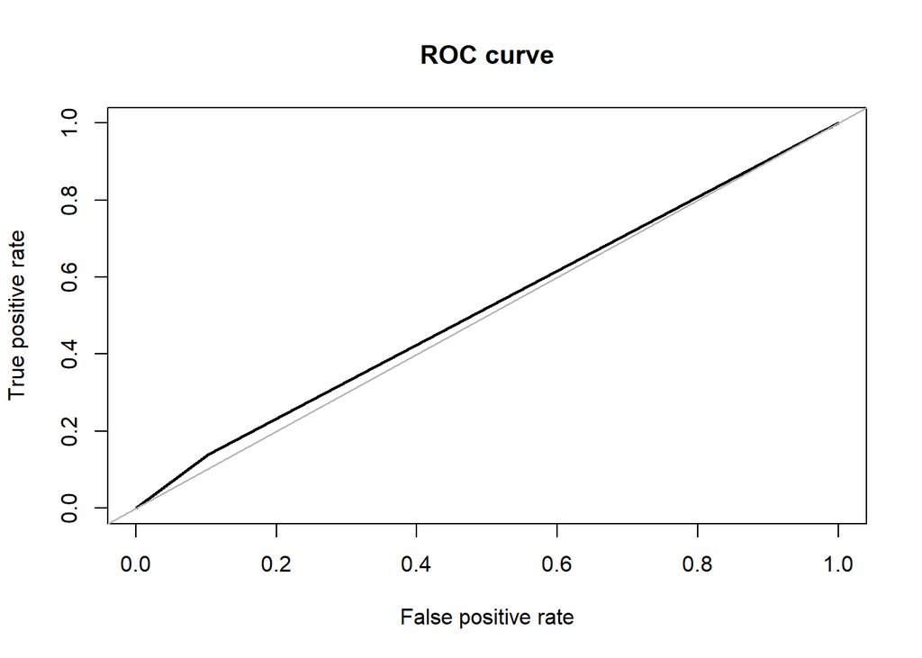

```
## Area under the curve (AUC): 0.518
```

```r
library(ROSE)

ROSE::roc.curve(Nvalid_norm$TARGET,
                Nknn_pred_k3_valid)
```

When analyzing the ROC curve, the curve almost matches the straight line, indicating that most of the correct positive guesses may be due to random chance rather than the predicting power of the model. The AUC is .518, which is pretty low. Let’s see if a different k number will improve our results.

## Model 1: kNN Model, k = 5

# Train Model

```r
Nknn_model1_k5 <- caret::knn3(TARGET ~ .,
                            data = Ntrain_norm, k = 5)
Nknn_model1_k5
```

```
## 5-nearest neighbor model
## Training set outcome distribution:
##
##    No   Yes
## 16857  4122
```

## Predict Training Set

```r
Nknn_pred_k5_train <- predict(Nknn_model1_k5,
                             newdata = Ntrain_norm[, -c(1)],
                             type = "class")
head(Nknn_pred_k5_train)
```

```
## [1] No  No  No  Yes No  No
## Levels: No Yes
```

## Evaluate

```r
confusionMatrix(Nknn_pred_k5_train, as.factor(Ntrain_norm[, 1]),
                positive = "Yes")
```

```
## Confusion Matrix and Statistics
##
##           Reference
## Prediction    No   Yes
##        No  16331  3116
##        Yes   526  1006
##
##                Accuracy : 0.8264
##                  95% CI : (0.8212, 0.8315)
##     No Information Rate : 0.8035
##     P-Value [Acc > NIR] : < 2.2e-16
##
##                   Kappa : 0.2791
##
##  Mcnemar's Test P-Value : < 2.2e-16
##
##             Sensitivity : 0.24406
##             Specificity : 0.96880
##          Pos Pred Value : 0.65666
##          Neg Pred Value : 0.83977
##              Prevalence : 0.19648
##          Detection Rate : 0.04795
##    Detection Prevalence : 0.07303
##       Balanced Accuracy : 0.60643
##
##        'Positive' Class : Yes
##
```

The accuracy of the k = 5 kNN model is .82 which is slightly lower than the k = 3. The sensitiviy rate is also much lower, and indicates that the model is not strong at predicting true positives.

## Model 1: Predict Validation Set

```r
Nknn_pred_k5_valid <- predict(Nknn_model1_k5,
                             newdata = Nvalid_norm[, -c(1)],
                             type = "class")
head(Nknn_pred_k5_valid)
```

```
## [1] No  No  No  No  Yes No
## Levels: No Yes
```

```r
confusionMatrix(Nknn_pred_k5_valid, as.factor(Nvalid_norm[, 1]),
                positive = "Yes")
```

```
## Confusion Matrix and Statistics
##
##           Reference
## Prediction   No  Yes
##        No  6814 1570
##        Yes  440  167
##
##                Accuracy : 0.7764
##                  95% CI : (0.7677, 0.785)
##     No Information Rate : 0.8068
##     P-Value [Acc > NIR] : 1
##
##                   Kappa : 0.0472
##
##  Mcnemar's Test P-Value : <2e-16
##
##             Sensitivity : 0.09614
##             Specificity : 0.93934
##          Pos Pred Value : 0.27512
##          Neg Pred Value : 0.81274
##              Prevalence : 0.19319
##          Detection Rate : 0.01857
##    Detection Prevalence : 0.06751
##       Balanced Accuracy : 0.51774
##
##        'Positive' Class : Yes
##
```

## Model 1 : Evaluate

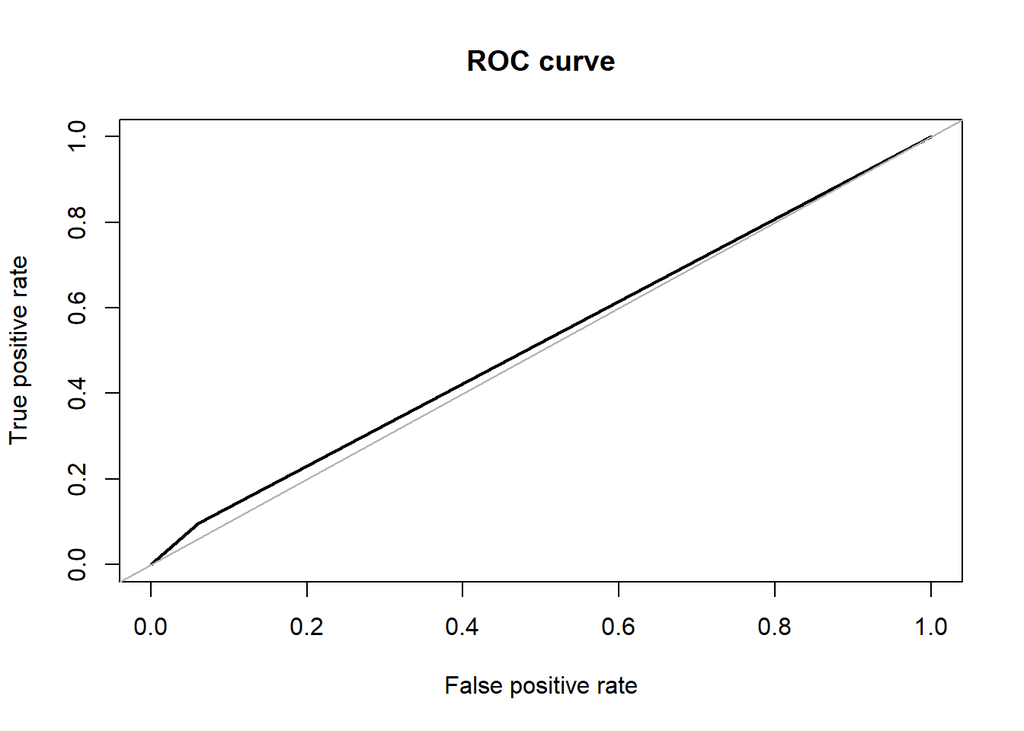

```
## Area under the curve (AUC): 0.518
```

```r
library(ROSE)

ROSE::roc.curve(Nvalid_norm$TARGET,
                Nknn_pred_k5_valid)
```

The AUC is also low at .518. The curve almost matches the diagonal line, indicating that the categorization of true positives may be due to random chance, and not the predicting power of the model.

One reason that the accuracy may be high but the sensitivity is low could be due to data imbalance.

```r
table(Ntrain$TARGET)
```

```
##
##    No   Yes
## 16857  4122
```

The training set has 16,857 no values, but only 4,122 yes values. Since the model has more NO records to predict trends from, it may be good at predicting these better than the yes.

Another reason is that the variables in the model may not be strong predictors of whether or not the individual is at high risk. Therefore, it is good to test out other variables. Additionally, since kNN models tend to perform better with fewer variables, we can try limiting the number of predictors we include in the model as well.

## Model 2: Load Data

```r
df <- read.csv("credit_fa2022_5.csv")
AD_df <- df [ , -c(1)]
AD_df2 <- AD_df[ , -c(1, 13, 18, 22:28, 35:40, 42, 63:65)]
AD_df1 <- AD_df[ , c(2:11, 13:17, 19:20)]
AD_df1_clean <- drop_na(AD_df1)

head(AD_df)
```

```
##   SK_ID_CURR TARGET NAME_CONTRACT_TYPE CODE_GENDER FLAG_OWN_CAR FLAG_OWN_REALTY
## 1     456106      0         Cash loans           M            N               N
## 2     418944      0    Revolving loans           F            N               Y
## 3     177366      0         Cash loans           M            Y               Y
## 4     205919      0         Cash loans           F            N               Y
## 5     255540      0         Cash loans           M            Y               Y
## 6     391755      0         Cash loans           F            N               Y
##   CNT_CHILDREN AMT_INCOME_TOTAL AMT_CREDIT AMT_ANNUITY AMT_GOODS_PRICE
## 1            0           112500   284400.0     16456.5          225000
## 2            1            85500   180000.0      9000.0          180000
## 3            1           157500   761872.5     59089.5          675000
## 4            0           202500   123637.5      8793.0          112500
## 5            0           144000   553806.0     26770.5          495000
## 6            0           360000  1125000.0     33025.5         1125000
##   NAME_TYPE_SUITE     NAME_INCOME_TYPE           NAME_EDUCATION_TYPE
```

[output cut: 111 more lines]

```r
str(AD_df2)
```

```
## 'data.frame':    30000 obs. of  47 variables:
##  $ TARGET                     : int  0 0 0 0 0 0 0 0 0 0 ...
##  $ NAME_CONTRACT_TYPE         : chr  "Cash loans" "Revolving loans" "Cash loans" "Cash loans" ...
##  $ CODE_GENDER                : chr  "M" "F" "M" "F" ...
##  $ FLAG_OWN_CAR               : chr  "N" "N" "Y" "N" ...
##  $ FLAG_OWN_REALTY            : chr  "N" "Y" "Y" "Y" ...
##  $ CNT_CHILDREN               : int  0 1 1 0 0 0 3 0 0 0 ...
##  $ AMT_INCOME_TOTAL           : num  112500 85500 157500 202500 144000 ...
##  $ AMT_CREDIT                 : num  284400 180000 761873 123638 553806 ...
##  $ AMT_ANNUITY                : num  16457 9000 59090 8793 26771 ...
##  $ AMT_GOODS_PRICE            : num  225000 180000 675000 112500 495000 ...
##  $ NAME_TYPE_SUITE            : chr  "Unaccompanied" "Unaccompanied" "Unaccompanied" "Unaccompanied" ...
##  $ NAME_EDUCATION_TYPE        : chr  "Secondary / secondary special" "Secondary / secondary special" "Secondary / secondary special" "Secondary / secondary special" ...
##  $ NAME_FAMILY_STATUS         : chr  "Civil marriage" "Married" "Married" "Married" ...
##  $ NAME_HOUSING_TYPE          : chr  "Rented apartment" "Municipal apartment" "House / apartment" "House / apartment" ...
```

[output cut: 33 more lines]

Any N/A values were then dropped in order to proceed with the kNN model.

## Model 2: Factorizing Data

```r
AD_df1_clean$TARGET <- factor(AD_df1_clean$TARGET,
                              levels = c("0", "1"),
                              labels = c("No", "Yes"))
AD_df1_clean$NAME_CONTRACT_TYPE <- as.factor(AD_df1_clean$NAME_CONTRACT_TYPE)
AD_df1_clean$CODE_GENDER <- as.factor(AD_df1_clean$CODE_GENDER)
AD_df1_clean$FLAG_OWN_CAR <- as.factor(AD_df1_clean$FLAG_OWN_CAR)
AD_df1_clean$FLAG_OWN_REALTY <- as.factor(AD_df1_clean$FLAG_OWN_REALTY)
AD_df1_clean$NAME_INCOME_TYPE <- as.factor(AD_df1_clean$NAME_INCOME_TYPE)
AD_df1_clean$NAME_EDUCATION_TYPE <- as.factor(AD_df1_clean$NAME_EDUCATION_TYPE)
AD_df1_clean$NAME_FAMILY_STATUS <- as.factor(AD_df1_clean$NAME_FAMILY_STATUS)
AD_df1_clean$NAME_HOUSING_TYPE <- as.factor(AD_df1_clean$NAME_HOUSING_TYPE)

str(AD_df1_clean)
```

```
## 'data.frame':    29970 obs. of  17 variables:
##  $ TARGET             : Factor w/ 2 levels "No","Yes": 1 1 1 1 1 1 1 1 1 1 ...
##  $ NAME_CONTRACT_TYPE : Factor w/ 2 levels "Cash loans","Revolving loans": 1 2 1 1 1 1 1 1 1 1 ...
##  $ CODE_GENDER        : Factor w/ 2 levels "F","M": 2 1 2 1 2 1 1 1 1 2 ...
##  $ FLAG_OWN_CAR       : Factor w/ 2 levels "N","Y": 1 1 2 1 2 1 2 1 1 1 ...
##  $ FLAG_OWN_REALTY    : Factor w/ 2 levels "N","Y": 1 2 2 2 2 2 2 2 2 2 ...
##  $ CNT_CHILDREN       : int  0 1 1 0 0 0 3 0 0 0 ...
##  $ AMT_INCOME_TOTAL   : num  112500 85500 157500 202500 144000 ...
##  $ AMT_CREDIT         : num  284400 180000 761873 123638 553806 ...
##  $ AMT_ANNUITY        : num  16457 9000 59090 8793 26771 ...
##  $ AMT_GOODS_PRICE    : num  225000 180000 675000 112500 495000 ...
##  $ NAME_INCOME_TYPE   : Factor w/ 7 levels "Commercial associate",..: 7 7 7 7 1 1 7 3 3 7 ...
##  $ NAME_EDUCATION_TYPE: Factor w/ 5 levels "Academic degree",..: 5 5 5 5 5 2 5 5 5 5 ...
##  $ NAME_FAMILY_STATUS : Factor w/ 5 levels "Civil marriage",..: 1 2 2 2 2 1 1 5 2 1 ...
##  $ NAME_HOUSING_TYPE  : Factor w/ 6 levels "Co-op apartment",..: 5 3 2 2 2 2 2 2 2 2 ...
##  $ DAYS_BIRTH         : int  -16083 -8144 -13097 -17775 -21791 -11340 -9749 -20651 -23317 -10570 ...
##  $ DAYS_REGISTRATION  : int  -3407 -1795 -5992 -7722 -7628 -553 -7868 -1469 -10425 -1404 ...
##  $ DAYS_ID_PUBLISH    : int  -3320 -824 -4504 -1324 -4030 -3612 -2357 -3592 -4041 -3007 ...
```

After selecting my variables, I factorized the outcome one and all the categorical ones in the data set.

## Model 2: Training-Validation Set

```r
set.seed(666)

AD_train_index <- sample(1:nrow(AD_df1_clean), 0.7 * nrow(AD_df1_clean))
AD_valid_index <- setdiff(1:nrow(AD_df1_clean), AD_train_index)

AD_train <- AD_df1_clean[AD_train_index, ]
AD_valid <- AD_df1_clean[AD_valid_index, ]

nrow(AD_train)
```

```
## [1] 20979
```

```r
nrow(AD_valid)
```

```
## [1] 8991
```

## Model 2: Normalize Training and Validation Set

```r
AD_train_norm <- AD_train
AD_valid_norm <- AD_valid

AD_norm_values <- preProcess(AD_train[, c(6:10, 15:17)],
                          method = c("center",
                                     "scale"))
AD_train_norm[, c(6:10, 15:17)] <- predict(AD_norm_values,
                               AD_train[, c(6:10, 15:17)])

AD_valid_norm[, c(6:10, 15:17)] <- predict(AD_norm_values,
                                AD_valid[, c(6:10, 15:17)])

head(AD_valid_norm)
```

```
##    TARGET NAME_CONTRACT_TYPE CODE_GENDER FLAG_OWN_CAR FLAG_OWN_REALTY
## 2      No    Revolving loans           F            N               Y
## 3      No         Cash loans           M            Y               Y
## 6      No         Cash loans           F            N               Y
## 9      No         Cash loans           F            N               Y
## 10     No         Cash loans           M            N               Y
## 12    Yes         Cash loans           F            Y               N
##    CNT_CHILDREN AMT_INCOME_TOTAL AMT_CREDIT AMT_ANNUITY AMT_GOODS_PRICE
## 2     0.7918812      -0.80077763 -1.0488346  -1.2644130      -0.9703849
## 3     0.7918812      -0.09857984  0.4437556   2.2762321       0.4151791
## 6    -0.5850666       1.87635143  1.3752321   0.4338625       1.6747827
## 9    -0.5850666       1.43747781  3.5777506   1.9645052       3.4886119
## 10   -0.5850666       0.55973058 -0.2025352   1.8019619      -0.1516425
## 12   -0.5850666       0.55973058 -0.3612307  -0.4151162      -0.5925038
##        NAME_INCOME_TYPE           NAME_EDUCATION_TYPE NAME_FAMILY_STATUS
## 2               Working Secondary / secondary special            Married
## 3               Working Secondary / secondary special            Married
## 6  Commercial associate              Higher education     Civil marriage
## 9             Pensioner Secondary / secondary special            Married
## 10              Working Secondary / secondary special     Civil marriage
## 12              Working              Higher education            Married
##      NAME_HOUSING_TYPE DAYS_BIRTH DAYS_REGISTRATION DAYS_ID_PUBLISH
## 2  Municipal apartment  1.7767496         0.9005460      1.40924954
## 3    House / apartment  0.6405569        -0.2981716     -1.02063857
## 6    House / apartment  1.0436036         1.2552773     -0.43165482
## 9    House / apartment -1.7038587        -1.5642938     -0.71492167
## 10   House / apartment  1.2202377         1.0122207     -0.03217594
## 12   House / apartment -0.3887379         1.0419244      1.56639991
```

## Model 2: Load in New Customers and Normalize

```r
library(dplyr)
new_cust <- read.csv("credit_test_fa2022_5.csv")
AD_new_cust<- new_cust [ , -c(1)]
AD_new_cust1 <- AD_new_cust[ , c(2:19)]

AD_new_cust1 <- AD_new_cust1 %>% mutate(CODE_GENDER = str_replace(CODE_GENDER, "FALSE", "F"))

AD_new_cust1$NAME_CONTRACT_TYPE <- as.factor(AD_new_cust1$NAME_CONTRACT_TYPE)
AD_new_cust1$CODE_GENDER <- as.factor(AD_new_cust1$CODE_GENDER)
AD_new_cust1$FLAG_OWN_CAR <- as.factor(AD_new_cust1$FLAG_OWN_CAR)
AD_new_cust1$FLAG_OWN_REALTY <- as.factor(AD_new_cust1$FLAG_OWN_REALTY)
AD_new_cust1$NAME_INCOME_TYPE <- as.factor(AD_new_cust1$NAME_INCOME_TYPE)
AD_new_cust1$NAME_EDUCATION_TYPE <- as.factor(AD_new_cust1$NAME_EDUCATION_TYPE)
AD_new_cust1$NAME_FAMILY_STATUS <- as.factor(AD_new_cust1$NAME_FAMILY_STATUS)
AD_new_cust1$NAME_HOUSING_TYPE <- as.factor(AD_new_cust1$NAME_HOUSING_TYPE)


str(AD_new_cust1)
```

```
## 'data.frame':    5 obs. of  18 variables:
##  $ NAME_CONTRACT_TYPE : Factor w/ 1 level "Cash loans": 1 1 1 1 1
##  $ CODE_GENDER        : Factor w/ 1 level "F": 1 1 1 1 1
##  $ FLAG_OWN_CAR       : Factor w/ 1 level "N": 1 1 1 1 1
##  $ FLAG_OWN_REALTY    : Factor w/ 1 level "Y": 1 1 1 1 1
##  $ CNT_CHILDREN       : int  0 0 0 0 0
##  $ AMT_INCOME_TOTAL   : int  202500 121500 144000 270000 157500
##  $ AMT_CREDIT         : num  407520 711081 380804 490496 493497
##  $ AMT_ANNUITY        : num  25061 53298 29597 36801 48942
##  $ AMT_GOODS_PRICE    : int  360000 630000 346500 454500 454500
##  $ NAME_TYPE_SUITE    : chr  "Unaccompanied" "Children" "Unaccompanied" "Unaccompanied" ...
##  $ NAME_INCOME_TYPE   : Factor w/ 2 levels "Commercial associate",..: 2 2 2 2 1
##  $ NAME_EDUCATION_TYPE: Factor w/ 2 levels "Higher education",..: 2 2 1 2 1
##  $ NAME_FAMILY_STATUS : Factor w/ 4 levels "Married","Separated",..: 3 1 1 2 4
##  $ NAME_HOUSING_TYPE  : Factor w/ 1 level "House / apartment": 1 1 1 1 1
##  $ DAYS_BIRTH         : int  -22881 -19938 -24422 -21642 -22101
##  $ DAYS_EMPLOYED      : int  365243 365243 365243 365243 -151
##  $ DAYS_REGISTRATION  : int  -5528 -10254 -7056 -3498 -7160
##  $ DAYS_ID_PUBLISH    : int  -5165 -3399 -4243 -4571 -4199
```

```r
AD_norm_values <- preProcess(AD_new_cust1[, c(6:10, 15:17)],
                          method = c("center",
                                     "scale"))
AD_new_cust_norm <- predict(AD_norm_values, AD_new_cust1)
AD_new_cust_norm
```

```
##   NAME_CONTRACT_TYPE CODE_GENDER FLAG_OWN_CAR FLAG_OWN_REALTY CNT_CHILDREN
## 1         Cash loans           F            N               Y            0
## 2         Cash loans           F            N               Y            0
## 3         Cash loans           F            N               Y            0
## 4         Cash loans           F            N               Y            0
## 5         Cash loans           F            N               Y            0
##   AMT_INCOME_TOTAL  AMT_CREDIT AMT_ANNUITY AMT_GOODS_PRICE NAME_TYPE_SUITE
## 1        0.3980032 -0.68689383  -1.1258345     -0.78716590   Unaccompanied
## 2       -0.9797002  1.65177353   1.1982038      1.59818532        Children
## 3       -0.5970048 -0.89272069  -0.7525069     -0.90643346   Unaccompanied
## 4        1.5460894 -0.04764145  -0.1595531      0.04770702   Unaccompanied
## 5       -0.3673876 -0.02451756   0.8396908      0.04770702   Unaccompanied
##       NAME_INCOME_TYPE           NAME_EDUCATION_TYPE   NAME_FAMILY_STATUS
## 1            Pensioner Secondary / secondary special Single / not married
## 2            Pensioner Secondary / secondary special              Married
## 3            Pensioner              Higher education              Married
## 4            Pensioner Secondary / secondary special            Separated
## 5 Commercial associate              Higher education                Widow
##   NAME_HOUSING_TYPE  DAYS_BIRTH DAYS_EMPLOYED DAYS_REGISTRATION DAYS_ID_PUBLISH
## 1 House / apartment -0.41564485     0.4472136         0.4723153           -5165
## 2 House / apartment  1.37219906     0.4472136        -1.4335608           -3399
## 3 House / apartment -1.35178739     0.4472136        -0.1438884           -4243
## 4 House / apartment  0.33703561     0.4472136         1.2909629           -4571
## 5 House / apartment  0.05819757    -1.7888544        -0.1858290           -4199
```

## Model 2: kNN Model, k = 3

I tested the kNN model with 3 different k values to find the ideal number of nearest neighbors. ## Train Model

```r
AD_knn_model_k3 <- caret::knn3(TARGET ~ .,
                            data = AD_train_norm, k = 3)
AD_knn_model_k3
```

```
## 3-nearest neighbor model
## Training set outcome distribution:
##
##    No   Yes
## 16857  4122
```

## Predict Training Set

```r
AD_knn_pred_k3_train <- predict(AD_knn_model_k3,
                             newdata = AD_train_norm[, -c(1)],
                             type = "class")
head(AD_knn_pred_k3_train)
```

```
## [1] No No No No No No
## Levels: No Yes
```

## Evaluate

```r
confusionMatrix(AD_knn_pred_k3_train, as.factor(AD_train_norm[, 1]),
                positive = "Yes")
```

```
## Confusion Matrix and Statistics
##
##           Reference
## Prediction    No   Yes
##        No  16119  2467
##        Yes   738  1655
##
##                Accuracy : 0.8472
##                  95% CI : (0.8423, 0.8521)
##     No Information Rate : 0.8035
##     P-Value [Acc > NIR] : < 2.2e-16
##
##                   Kappa : 0.4251
##
##  Mcnemar's Test P-Value : < 2.2e-16
##
##             Sensitivity : 0.40150
##             Specificity : 0.95622
##          Pos Pred Value : 0.69160
##          Neg Pred Value : 0.86727
##              Prevalence : 0.19648
##          Detection Rate : 0.07889
##    Detection Prevalence : 0.11407
##       Balanced Accuracy : 0.67886
##
##        'Positive' Class : Yes
##
```

Looking at the confusion matrix, we can see that the model has a strong accuracy score at .8472, indicating that the model actually predicted about 85% of the records in the training data. However, the model does have a low sensitivity score of .40150, indicating that the recall rate is fairly poor, and it is not able to accurately predict a true positive. The specificity score is high at .95622, indicating that the model is very good at accurately predicting true negatives.

## Model 2: kNN Model, k = 5

## Train Model

```r
AD_knn_model_k5 <- caret::knn3(TARGET ~ .,
                            data = AD_train_norm, k = 5)
AD_knn_model_k5
```

```
## 5-nearest neighbor model
## Training set outcome distribution:
##
##    No   Yes
## 16857  4122
```

## Predict Training Set

```r
AD_knn_pred_k5_train <- predict(AD_knn_model_k5,
                             newdata = AD_train_norm[, -c(1)],
                             type = "class")
head(AD_knn_pred_k5_train)
```

```
## [1] Yes No  No  No  No  No
## Levels: No Yes
```

## Evaluate

```r
confusionMatrix(AD_knn_pred_k5_train, as.factor(AD_train_norm[, 1]),
                positive = "Yes")
```

```
## Confusion Matrix and Statistics
##
##           Reference
## Prediction    No   Yes
##        No  16258  3094
##        Yes   599  1028
##
##                Accuracy : 0.824
##                  95% CI : (0.8187, 0.8291)
##     No Information Rate : 0.8035
##     P-Value [Acc > NIR] : 2.238e-14
##
##                   Kappa : 0.2772
##
##  Mcnemar's Test P-Value : < 2.2e-16
##
##             Sensitivity : 0.24939
##             Specificity : 0.96447
##          Pos Pred Value : 0.63184
##          Neg Pred Value : 0.84012
##              Prevalence : 0.19648
##          Detection Rate : 0.04900
##    Detection Prevalence : 0.07755
##       Balanced Accuracy : 0.60693
##
##        'Positive' Class : Yes
##
```

Looking at the confusion matrix, we can see that the model has a strong accuracy score at .824, indicating that the model actually predicted about 82% of the records in the training data. However, the model does have a low sensitivity score of .24939, indicating that the recall rate is poor, and it is not able to accurately predict a true positive. The specificity score is high at .96447, indicating that the model is very good at accurately predicting true negatives.

## Model 2: kNN Model, k = 7

## Train Model

```r
AD_knn_model_k7 <- caret::knn3(TARGET ~ .,
                            data = AD_train_norm, k = 7)
AD_knn_model_k7
```

```
## 7-nearest neighbor model
## Training set outcome distribution:
##
##    No   Yes
## 16857  4122
```

## Predict Training Set

```r
AD_knn_pred_k7_train <- predict(AD_knn_model_k7,
                             newdata = AD_train_norm[, -c(1)],
                             type = "class")
head(AD_knn_pred_k7_train)
```

```
## [1] Yes No  No  No  No  No
## Levels: No Yes
```

## Evaluate

```r
confusionMatrix(AD_knn_pred_k7_train, as.factor(AD_train_norm[, 1]),
                positive = "Yes")
```

```
## Confusion Matrix and Statistics
##
##           Reference
## Prediction    No   Yes
##        No  16415  3446
##        Yes   442   676
##
##                Accuracy : 0.8147
##                  95% CI : (0.8093, 0.8199)
##     No Information Rate : 0.8035
##     P-Value [Acc > NIR] : 2.202e-05
##
##                   Kappa : 0.1901
##
##  Mcnemar's Test P-Value : < 2.2e-16
##
##             Sensitivity : 0.16400
##             Specificity : 0.97378
##          Pos Pred Value : 0.60465
##          Neg Pred Value : 0.82649
##              Prevalence : 0.19648
##          Detection Rate : 0.03222
##    Detection Prevalence : 0.05329
##       Balanced Accuracy : 0.56889
##
##        'Positive' Class : Yes
##
```

Looking at the confusion matrix, we can see that the model has a strong accuracy score at .8147, indicating that the model actually predicted about 81% of the records in the training data. However, the model does have a low sensitivity score of .16400, indicating that the recall rate is poor, and it is not able to accurately predict a true positive. The specificity score is high at .97378, indicating that the model is very good at accurately predicting true negatives.

## Model 2: Predict Validation Set, k = 3

```r
AD_knn_pred_k3_valid <- predict(AD_knn_model_k3,
                             newdata = AD_valid_norm,
                             type = "class")
head(AD_knn_pred_k3_valid)
```

```
## [1] Yes Yes No  No  Yes No
## Levels: No Yes
```

## Evaluate

```r
confusionMatrix(AD_knn_pred_k3_valid, as.factor(AD_valid_norm[, 1]),
                positive = "Yes")
```

```
## Confusion Matrix and Statistics
##
##           Reference
## Prediction   No  Yes
##        No  6524 1479
##        Yes  730  258
##
##                Accuracy : 0.7543
##                  95% CI : (0.7453, 0.7632)
##     No Information Rate : 0.8068
##     P-Value [Acc > NIR] : 1
##
##                   Kappa : 0.0573
##
##  Mcnemar's Test P-Value : <2e-16
##
##             Sensitivity : 0.1485
##             Specificity : 0.8994
##          Pos Pred Value : 0.2611
##          Neg Pred Value : 0.8152
##              Prevalence : 0.1932
##          Detection Rate : 0.0287
##    Detection Prevalence : 0.1099
##       Balanced Accuracy : 0.5239
##
##        'Positive' Class : Yes
##
```

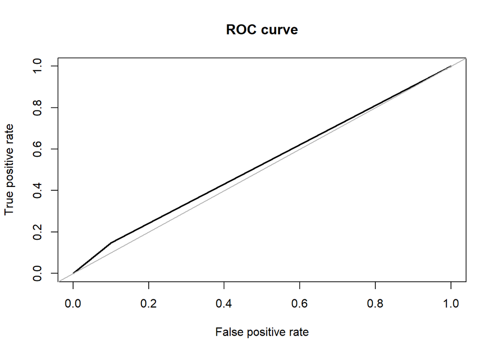

```
## Area under the curve (AUC): 0.524
```

```r
library(ROSE)

ROSE::roc.curve(AD_valid_norm$TARGET,
                AD_knn_pred_k3_valid)
```

The AUC is fairly low at .524. The curve almost matches the diagonal line, indicating that the categorization of true positives may be due to random chance, and not the predicting power of the model.

One reason that the accuracy may be high but the sensitivity is low could be due to data imbalance.

## Model 2: Predict Validation Set, k = 5

```r
AD_knn_pred_k5_valid <- predict(AD_knn_model_k5,
                             newdata = AD_valid_norm[, -c(1)],
                             type = "class")
head(AD_knn_pred_k5_valid)
```

```
## [1] Yes No  No  No  No  No
## Levels: No Yes
```

## Evaluate

```r
confusionMatrix(AD_knn_pred_k5_valid, as.factor(AD_valid_norm[, 1]),
                positive = "Yes")
```

```
## Confusion Matrix and Statistics
##
##           Reference
## Prediction   No  Yes
##        No  6816 1553
##        Yes  438  184
##
##                Accuracy : 0.7786
##                  95% CI : (0.7698, 0.7871)
##     No Information Rate : 0.8068
##     P-Value [Acc > NIR] : 1
##
##                   Kappa : 0.0603
##
##  Mcnemar's Test P-Value : <2e-16
##
##             Sensitivity : 0.10593
##             Specificity : 0.93962
##          Pos Pred Value : 0.29582
##          Neg Pred Value : 0.81443
##              Prevalence : 0.19319
##          Detection Rate : 0.02046
##    Detection Prevalence : 0.06918
##       Balanced Accuracy : 0.52277
##
##        'Positive' Class : Yes
##
```

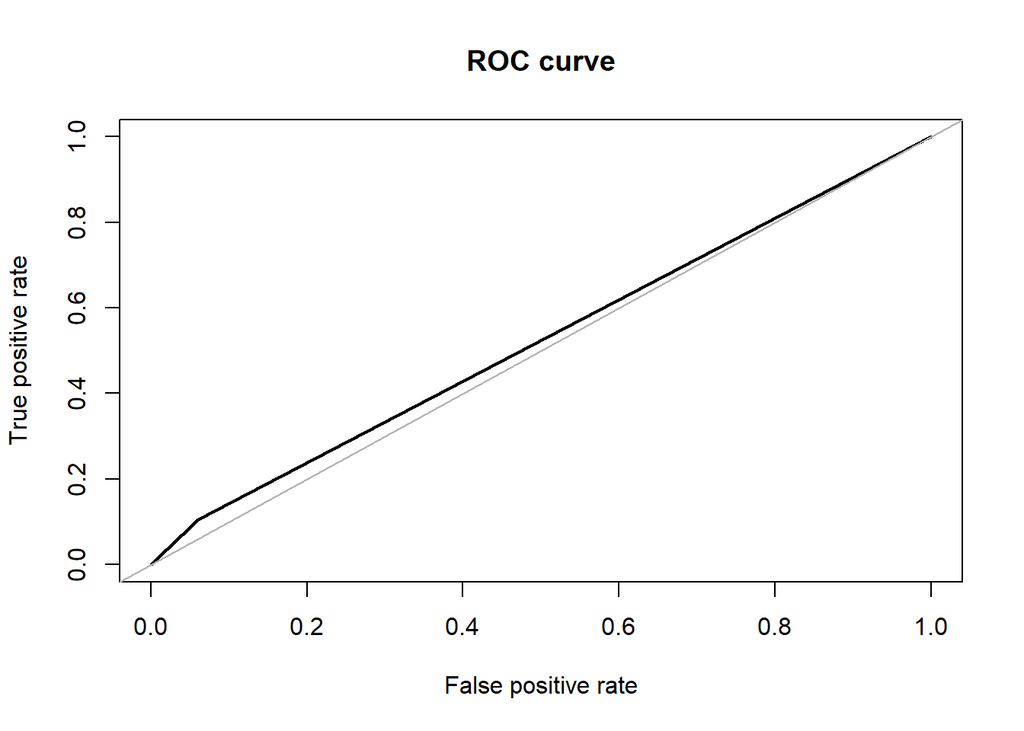

```
## Area under the curve (AUC): 0.523
```

```r
ROSE::roc.curve(AD_valid_norm$TARGET,
                AD_knn_pred_k5_valid)
```

The AUC is fairly low at .523. The curve almost matches the diagonal line, indicating that the categorization of true positives may be due to random chance, and not the predicting power of the model.

One reason that the accuracy may be high but the sensitivity is low could be due to data imbalance.

## Model 2: Predict Validation Set, k = 7

```r
AD_knn_pred_k7_valid <- predict(AD_knn_model_k7,
                             newdata = AD_valid_norm[, -c(1)],
                             type = "class")
head(AD_knn_pred_k7_valid)
```

```
## [1] Yes No  No  No  No  No
## Levels: No Yes
```

## Evaluate

```r
confusionMatrix(AD_knn_pred_k5_valid, as.factor(AD_valid_norm[, 1]),
                positive = "Yes")
```

[output not shown]

[figure not shown]

[output not shown]

```r
ROSE::roc.curve(AD_valid_norm$TARGET,
                AD_knn_pred_k5_valid)
```

One reason that the accuracy may be high but the sensitivity is low could be due to data imbalance.

## Model 3: Load Data

```r
ak_df <- read.csv("credit_fa2022_5.csv")
ak_df <- ak_df [ , -c(1)]
ak_df1 <- ak_df[ , c(2:3,5:11,29:31, 65:67)]
ak_df1_clean <- drop_na(ak_df1)
```

After loading the data, I went through the variables and selected a few to predict “Target.” The variables I chose were Contract Type, Owns Car, Owns Realty, Number of Children, Total Income, Amount of Credit, Amount Annuity, Amount of Goods Price, Number of Family Members, region rating of where client lives, region rating of where client lives taking into account city, Amount of Inquires in the Month, Amount of Inquires in the Quarter, and Amount of Inquires in the Year.

I also dropped all the missing values from the data set.

## Model 3: Factorizing Data

```r
ak_df1_clean$TARGET <- factor(ak_df1_clean$TARGET,
                              levels = c("0", "1"),
                              labels = c("No", "Yes"))
ak_df1_clean$NAME_CONTRACT_TYPE <- as.factor(ak_df1_clean$NAME_CONTRACT_TYPE)
ak_df1_clean$FLAG_OWN_CAR <- as.factor(ak_df1_clean$FLAG_OWN_CAR)
ak_df1_clean$FLAG_OWN_REALTY <- as.factor(ak_df1_clean$FLAG_OWN_REALTY)

str(ak_df1_clean)
```

```
## 'data.frame':    25859 obs. of  15 variables:
##  $ TARGET                     : Factor w/ 2 levels "No","Yes": 1 1 1 1 1 1 1 1 2 2 ...
##  $ NAME_CONTRACT_TYPE         : Factor w/ 2 levels "Cash loans","Revolving loans": 1 1 1 1 1 1 1 1 1 1 ...
##  $ FLAG_OWN_CAR               : Factor w/ 2 levels "N","Y": 1 2 1 2 1 2 1 1 2 1 ...
##  $ FLAG_OWN_REALTY            : Factor w/ 2 levels "N","Y": 1 2 2 2 2 2 2 2 1 1 ...
##  $ CNT_CHILDREN               : int  0 1 0 0 0 3 0 0 0 1 ...
##  $ AMT_INCOME_TOTAL           : num  112500 157500 202500 144000 360000 ...
##  $ AMT_CREDIT                 : num  284400 761873 123638 553806 1125000 ...
##  $ AMT_ANNUITY                : num  16457 59090 8793 26771 33026 ...
##  $ AMT_GOODS_PRICE            : num  225000 675000 112500 495000 1125000 ...
##  $ CNT_FAM_MEMBERS            : int  2 3 2 2 2 5 1 2 2 3 ...
##  $ REGION_RATING_CLIENT       : int  2 2 2 2 3 2 2 2 2 2 ...
##  $ REGION_RATING_CLIENT_W_CITY: int  2 2 2 2 3 2 2 2 2 2 ...
##  $ AMT_REQ_CREDIT_BUREAU_MON  : int  0 0 0 1 0 0 0 0 0 0 ...
##  $ AMT_REQ_CREDIT_BUREAU_QRT  : int  0 1 0 0 0 0 0 0 0 1 ...
##  $ AMT_REQ_CREDIT_BUREAU_YEAR : int  1 4 2 2 1 0 2 1 3 0 ...
```

I factorized the outcome variable and the categorical variables.

## Model 3: Training-Validation Set

```r
set.seed(666)

ak_train_index <- sample(1:nrow(ak_df1_clean), 0.7 * nrow(ak_df1_clean))
ak_valid_index <- setdiff(1:nrow(ak_df1_clean), ak_train_index)

ak_train <- ak_df1_clean[ak_train_index, ]
ak_valid <- ak_df1_clean[ak_valid_index, ]

nrow(ak_train)
```

```
## [1] 18101
```

```r
nrow(ak_valid)
```

```
## [1] 7758
```

I created sample and validation sets. The training index spit was 70%, and the validation was 30%.

## Model 3: Normalize Training and Validation Set

```r
ak_train_norm <- ak_train
ak_valid_norm <- ak_valid

ak_norm_values <- preProcess(ak_train[, c(5:15)],
                          method = c("center",
                                     "scale"))
ak_train_norm[, c(5:15)] <- predict(ak_norm_values,
                               ak_train[, c(5:15)])

ak_valid_norm[, c(5:15)] <- predict(ak_norm_values,
                                ak_valid[, c(5:15)])
head(ak_valid_norm)
```

```
##    TARGET NAME_CONTRACT_TYPE FLAG_OWN_CAR FLAG_OWN_REALTY CNT_CHILDREN
## 2      No         Cash loans            Y               Y    0.7992207
## 3      No         Cash loans            N               Y   -0.5874076
## 6      No         Cash loans            Y               Y    3.5724773
## 9     Yes         Cash loans            Y               N   -0.5874076
## 10    Yes         Cash loans            N               N    0.7992207
## 11     No         Cash loans            N               Y    2.1858490
##    AMT_INCOME_TOTAL AMT_CREDIT AMT_ANNUITY AMT_GOODS_PRICE CNT_FAM_MEMBERS
## 2        -0.1238084  0.4214795   2.2811200       0.3937528       0.9224240
## 3         0.3124567 -1.2033458  -1.2911461      -1.1708792      -0.1817155
## 6        -0.5600735 -1.1515067  -1.1623438      -1.0832598       3.1307029
## 9         0.5305893 -0.3774378  -0.4230889      -0.6076117      -0.1817155
## 10       -0.1238084 -0.3724887  -0.1309666      -0.2321000       0.9224240
## 11        1.4031196  1.1965451   0.8137966       1.0196055       0.9224240
##    REGION_RATING_CLIENT REGION_RATING_CLIENT_W_CITY AMT_REQ_CREDIT_BUREAU_MON
## 2            -0.1244014                 -0.08481388                -0.2959034
## 3            -0.1244014                 -0.08481388                -0.2959034
## 6            -0.1244014                 -0.08481388                -0.2959034
## 9            -0.1244014                 -0.08481388                -0.2959034
## 10           -0.1244014                 -0.08481388                -0.2959034
## 11           -2.0927495                 -2.07860098                -0.2959034
##    AMT_REQ_CREDIT_BUREAU_QRT AMT_REQ_CREDIT_BUREAU_YEAR
## 2                  0.3542141                 1.09578413
## 3                 -0.1373999                 0.02658093
## 6                 -0.1373999                -1.04262227
## 9                 -0.1373999                 0.56118253
## 10                 0.3542141                -1.04262227
## 11                 0.3542141                -0.50802067
```

## Model 3: Load in New Customers and Normalize

```r
ak_new_cust <- read.csv("credit_test_fa2022_5.csv")
ak_new_cust<- ak_new_cust [ , -c(1)]
ak_new_cust1 <- ak_new_cust[ , c(2, 4:10, 28:30, 64:66)]
ak_new_cust1 <- drop_na(ak_new_cust1)

ak_new_cust1$NAME_CONTRACT_TYPE <- as.factor(ak_new_cust1$NAME_CONTRACT_TYPE)
ak_new_cust1$FLAG_OWN_CAR <- as.factor(ak_new_cust1$FLAG_OWN_CAR)
ak_new_cust1$FLAG_OWN_REALTY <- as.factor(ak_new_cust1$FLAG_OWN_REALTY)

str(ak_new_cust1)
```

```
## 'data.frame':    4 obs. of  14 variables:
##  $ NAME_CONTRACT_TYPE         : Factor w/ 1 level "Cash loans": 1 1 1 1
##  $ FLAG_OWN_CAR               : Factor w/ 1 level "N": 1 1 1 1
##  $ FLAG_OWN_REALTY            : Factor w/ 1 level "Y": 1 1 1 1
##  $ CNT_CHILDREN               : int  0 0 0 0
##  $ AMT_INCOME_TOTAL           : int  202500 144000 270000 157500
##  $ AMT_CREDIT                 : num  407520 380804 490496 493497
##  $ AMT_ANNUITY                : num  25061 29597 36801 48942
##  $ AMT_GOODS_PRICE            : int  360000 346500 454500 454500
##  $ CNT_FAM_MEMBERS            : int  1 2 1 1
##  $ REGION_RATING_CLIENT       : int  2 2 1 2
##  $ REGION_RATING_CLIENT_W_CITY: int  2 2 1 2
##  $ AMT_REQ_CREDIT_BUREAU_MON  : int  0 0 0 0
##  $ AMT_REQ_CREDIT_BUREAU_QRT  : int  1 0 0 0
##  $ AMT_REQ_CREDIT_BUREAU_YEAR : int  6 7 0 0
```

```r
ak_norm_values <- preProcess(ak_new_cust1[, c(4:14)],
                          method = c("center",
                                     "scale"))
ak_new_cust_norm <- predict(ak_norm_values, ak_new_cust1)
ak_new_cust_norm
```

```
##   NAME_CONTRACT_TYPE FLAG_OWN_CAR FLAG_OWN_REALTY CNT_CHILDREN AMT_INCOME_TOTAL
## 1         Cash loans            N               Y            0        0.1584443
## 2         Cash loans            N               Y            0       -0.8714438
## 3         Cash loans            N               Y            0        1.3467767
## 4         Cash loans            N               Y            0       -0.6337773
##   AMT_CREDIT AMT_ANNUITY AMT_GOODS_PRICE CNT_FAM_MEMBERS REGION_RATING_CLIENT
## 1 -0.6179743  -0.9637127      -0.7472416            -0.5                  0.5
## 2 -1.0822761  -0.5282925      -0.9771621             1.5                  0.5
## 3  0.8240439   0.1632826       0.8622019            -0.5                 -1.5
## 4  0.8762065   1.3287226       0.8622019            -0.5                  0.5
##   REGION_RATING_CLIENT_W_CITY AMT_REQ_CREDIT_BUREAU_MON
## 1                         0.5                         0
## 2                         0.5                         0
## 3                        -1.5                         0
## 4                         0.5                         0
##   AMT_REQ_CREDIT_BUREAU_QRT AMT_REQ_CREDIT_BUREAU_YEAR
## 1                       1.5                  0.7284928
## 2                      -0.5                  0.9933993
## 3                      -0.5                 -0.8609460
## 4                      -0.5                 -0.8609460
```

## Model 3: kNN Model, k = 3

## Train Model

Creating multiple kNN models with different k values to see which one produces the best outcome.

```r
ak_knn_model_3 <- caret::knn3(TARGET ~ ., data = ak_train_norm, k = 3)
ak_knn_model_3
```

```
## 3-nearest neighbor model
## Training set outcome distribution:
##
##    No   Yes
## 14673  3428
```

## Predict Training Set

```r
ak_knn_pred_train_3 <- predict(ak_knn_model_3, newdata = ak_train_norm[, -c(1)], type = "class")

confusionMatrix(ak_knn_pred_train_3, as.factor(ak_train_norm[, c(1)]), positive = "Yes")
```

```
## Confusion Matrix and Statistics
##
##           Reference
## Prediction    No   Yes
##        No  14105  2111
##        Yes   568  1317
##
##                Accuracy : 0.852
##                  95% CI : (0.8467, 0.8571)
##     No Information Rate : 0.8106
##     P-Value [Acc > NIR] : < 2.2e-16
##
##                   Kappa : 0.4175
##
##  Mcnemar's Test P-Value : < 2.2e-16
##
##             Sensitivity : 0.38419
##             Specificity : 0.96129
##          Pos Pred Value : 0.69867
##          Neg Pred Value : 0.86982
##              Prevalence : 0.18938
##          Detection Rate : 0.07276
##    Detection Prevalence : 0.10414
##       Balanced Accuracy : 0.67274
##
##        'Positive' Class : Yes
##
```

The accuracy of this model was 85%, however, the sensitivity was only 38% showing that it is not effective at identifying “Yes.” The specificity was high at 96%.

#Predict Validation Set

```r
ak_knn_pred_valid_3 <- predict(ak_knn_model_3, newdata = ak_valid_norm[, -c(1)], type = "class")

confusionMatrix(ak_knn_pred_valid_3, as.factor(ak_valid_norm[, c(1)]), positive = "Yes")
```

```
## Confusion Matrix and Statistics
##
##           Reference
## Prediction   No  Yes
##        No  5691 1270
##        Yes  607  190
##
##                Accuracy : 0.7581
##                  95% CI : (0.7484, 0.7676)
##     No Information Rate : 0.8118
##     P-Value [Acc > NIR] : 1
##
##                   Kappa : 0.0409
##
##  Mcnemar's Test P-Value : <2e-16
##
##             Sensitivity : 0.13014
##             Specificity : 0.90362
##          Pos Pred Value : 0.23839
##          Neg Pred Value : 0.81755
##              Prevalence : 0.18819
##          Detection Rate : 0.02449
##    Detection Prevalence : 0.10273
##       Balanced Accuracy : 0.51688
##
##        'Positive' Class : Yes
##
```

The accuracy was 75.8%, but, once again, the sensitivity was low at 13%, while the specificity was high at 90% ## Predict New Customers, k = 3

```r
ak_new_cust_predict_3 <- predict(ak_knn_model_3, newdata = ak_new_cust_norm,
                            type = "class")
ak_new_cust_predict_3
```

```
## [1] No No No No
## Levels: No Yes
```

The model predicted “No” for all the new customers.

## Model 3: kNN Model, k = 5

## Train Model

```r
ak_knn_model_5 <- caret::knn3(TARGET ~ ., data = ak_train_norm, k = 5)
ak_knn_model_5
```

```
## 5-nearest neighbor model
## Training set outcome distribution:
##
##    No   Yes
## 14673  3428
```

## Predict Training Set and Validation Set

```r
ak_knn_pred_train_5 <- predict(ak_knn_model_5, newdata = ak_train_norm[, -c(1)], type = "class")

confusionMatrix(ak_knn_pred_train_5, as.factor(ak_train_norm[, c(1)]))
```

```
## Confusion Matrix and Statistics
##
##           Reference
## Prediction    No   Yes
##        No  14271  2719
##        Yes   402   709
##
##                Accuracy : 0.8276
##                  95% CI : (0.822, 0.8331)
##     No Information Rate : 0.8106
##     P-Value [Acc > NIR] : 2.03e-09
##
##                   Kappa : 0.2421
##
##  Mcnemar's Test P-Value : < 2.2e-16
##
##             Sensitivity : 0.9726
##             Specificity : 0.2068
##          Pos Pred Value : 0.8400
##          Neg Pred Value : 0.6382
##              Prevalence : 0.8106
##          Detection Rate : 0.7884
##    Detection Prevalence : 0.9386
##       Balanced Accuracy : 0.5897
##
##        'Positive' Class : No
##
```

```r
ak_knn_pred_valid_5 <- predict(ak_knn_model_5, newdata = ak_valid_norm[, -c(1)], type = "class")

confusionMatrix(ak_knn_pred_valid_5, as.factor(ak_valid_norm[, c(1)]), positive = "Yes")
```

```
## Confusion Matrix and Statistics
##
##           Reference
## Prediction   No  Yes
##        No  5921 1349
##        Yes  377  111
##
##                Accuracy : 0.7775
##                  95% CI : (0.7681, 0.7867)
##     No Information Rate : 0.8118
##     P-Value [Acc > NIR] : 1
##
##                   Kappa : 0.0217
##
##  Mcnemar's Test P-Value : <2e-16
##
##             Sensitivity : 0.07603
##             Specificity : 0.94014
##          Pos Pred Value : 0.22746
##          Neg Pred Value : 0.81444
##              Prevalence : 0.18819
##          Detection Rate : 0.01431
##    Detection Prevalence : 0.06290
##       Balanced Accuracy : 0.50808
##
##        'Positive' Class : Yes
##
```

On the validation set, the accuracy was 77%, but the sensitivity was low at 7%. The specificity was high at 94%.

## Predict New Customers, k = 5

```r
ak_new_cust_predict_5 <- predict(ak_knn_model_5, newdata = ak_new_cust_norm,
                            type = "class")
ak_new_cust_predict_5
```

```
## [1] No No No No
## Levels: No Yes
```

The model predicted “No” for all the new customers.

## Model 3: kNN Model, k = 7

## Train Model

```r
ak_knn_model_7 <- caret::knn3(TARGET ~ ., data = ak_train_norm, k = 7)
ak_knn_model_7
```

```
## 7-nearest neighbor model
## Training set outcome distribution:
##
##    No   Yes
## 14673  3428
```

## Predict Training Set

```r
ak_knn_pred_train_7 <- predict(ak_knn_model_7, newdata = ak_train_norm[, -c(1)], type = "class")

confusionMatrix(ak_knn_pred_train_7, as.factor(ak_train_norm[, c(1)]))
```

```
## Confusion Matrix and Statistics
##
##           Reference
## Prediction    No   Yes
##        No  14400  3000
##        Yes   273   428
##
##                Accuracy : 0.8192
##                  95% CI : (0.8135, 0.8248)
##     No Information Rate : 0.8106
##     P-Value [Acc > NIR] : 0.001609
##
##                   Kappa : 0.1528
##
##  Mcnemar's Test P-Value : < 2.2e-16
##
##             Sensitivity : 0.9814
##             Specificity : 0.1249
##          Pos Pred Value : 0.8276
##          Neg Pred Value : 0.6106
##              Prevalence : 0.8106
##          Detection Rate : 0.7955
##    Detection Prevalence : 0.9613
##       Balanced Accuracy : 0.5531
##
##        'Positive' Class : No
##
```

```r
ak_knn_pred_valid_7 <- predict(ak_knn_model_7, newdata = ak_valid_norm[, -c(1)], type = "class")

confusionMatrix(ak_knn_pred_valid_7, as.factor(ak_valid_norm[, c(1)]), positive = "Yes")
```

```
## Confusion Matrix and Statistics
##
##           Reference
## Prediction   No  Yes
##        No  6060 1384
##        Yes  238   76
##
##                Accuracy : 0.7909
##                  95% CI : (0.7817, 0.7999)
##     No Information Rate : 0.8118
##     P-Value [Acc > NIR] : 1
##
##                   Kappa : 0.0204
##
##  Mcnemar's Test P-Value : <2e-16
##
##             Sensitivity : 0.052055
##             Specificity : 0.962210
##          Pos Pred Value : 0.242038
##          Neg Pred Value : 0.814078
##              Prevalence : 0.188193
##          Detection Rate : 0.009796
##    Detection Prevalence : 0.040474
##       Balanced Accuracy : 0.507133
##
##        'Positive' Class : Yes
##
```

On the validation set, the accuracy was 79%. The sensitivity was 5%, while the specificity was 96%.

## Predict New Customers, k = 7

## Train Model

```r
ak_new_cust_predict_7 <- predict(ak_knn_model_7, newdata = ak_new_cust_norm,
                            type = "class")
ak_new_cust_predict_7
```

```
## [1] No No No No
## Levels: No Yes
```

The model predicted “No” for all the new customers.

## Evaluate

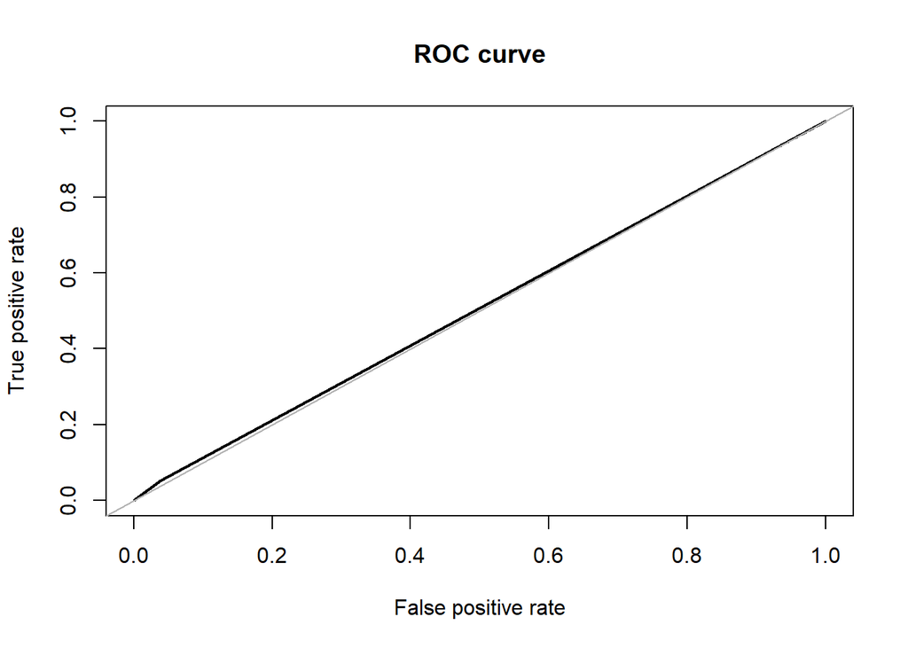

```
## Area under the curve (AUC): 0.507
```

```r
ROSE::roc.curve(ak_valid_norm$TARGET,
                ak_knn_pred_valid_7)
```

The ROC curve almost perfectly matches the straight line, and the area under the curve is .507 which is low.

## Predict New Customer w/ Best Model

We decided that Model 2, K = 3 was the best model since it had the highest sensitivity score of .14 while maintaining a high level of accuracy at .75 with a specificity score of .89. Although .14 is still low, this is the model that gives us the highest accuracy of capturing the true positive rate. Since it is preferable that we falsely calculate too many high-risk people rather than too little, we value the model with the highest sensitivity over the model with the highest specificity.

```r
new_cust_predict <- predict(AD_knn_model_k3, newdata = AD_new_cust_norm,
                            type = "class")
new_cust_predict
```

```
## [1] No No No No No
## Levels: No Yes
```

Our model predicted that all the new customers would be categorized as not high risk. We are more confident about true negatives rather than true positives. Therefore, in future steps, we can utilize a decision tree with weighted sampling to help with the data imbalance problem.